# Phenotype plasticity under ERBB and CDK4 inhibition treatment: Hallmark G2M checkpoint example

Jason Griffiths

2023-08-23

## Packages

```r
require(data.table);require(dplyr);require(tidyr);require(mgcv);require(ggplot2)
```

## Load data

```r
rm(list=ls())
fileloc <- ("/Users/jason/Jason Griffiths Dropbox/jason griffiths/Cancer_pheno_evo/data/Lab U01/bulkRNA example data/")
filenm1 <- "sh10050_mcf7_resistant_H_HALLMARK_G2M_CHECKPOINT_data_model_input.txt"
filenm2 <- "sh10050_mcf7_sensitive_H_HALLMARK_G2M_CHECKPOINT_data_model_input.txt"

dd <- rbind(fread(paste0(fileloc,filenm1)),
            fread(paste0(fileloc,filenm2)))
```

## Organize data

```r
# Set DMSO as reference treatment state
dd$Treatment<- factor(dd$Treatment,levels=c("DMSO","Afat","Ribo","Comb"))
# Set Sensitive (Sen) as reference cell state
dd$State<- factor(dd$State,levels=c("Sen","RiboR"))

# Set short term time under drug variable (timeunderdrug) as factor
dd$timeunderdrug<-as.factor(dd$timeunderdrug)

# Make indicator variables showing if each drug is given and if the combination is given
# This encodes for main drug effects and combination treatment effects (synergy)
dd[,RiboTreated:=0 ]
dd[Treatment%in%c("Ribo","Comb"),RiboTreated:=1 ]
dd[,AfatTreated:=0 ]
dd[Treatment%in%c("Afat","Comb"),AfatTreated:=1 ]
dd[,CombTreated:=0 ]
dd[Treatment%in%c("Comb"),CombTreated:=1 ]

# Create indicator if time is 6/24 hours after a drugging event
dd[,isHour6:= 1*(timeunderdrug==6)]
dd[,isHour24:=1*( timeunderdrug==24)]

# Create variables for long term phenotype trends in resistant and sensitive cells under each treatment relative to DMSO
# reparameterize in terms of cumulative time (days) of the experiment
dd[, CumDay6:=0]
dd[day>=6, CumDay6:=1]
dd[, CumDay12:=0]
dd[day>=12, CumDay12:=1]
dd[, CumDay18:=0]
dd[day>=18, CumDay18:=1]

# Plasticity under DMSO variables
dd[,plastHour6:= Hour*isHour6]
dd[,plastHour24:= Hour*isHour24]
dd[,RiboRplastHour6:= (State=="RiboR")*Hour*isHour6]
dd[,RiboRplastHour24:= (State=="RiboR")*Hour*isHour24]

# Plasticity under drug x variables
# Encode predictors in terms of main and synergistic effects of treatments on cell rewiring
dd[,plastHour.AfatTreated6:= (Hour.afat+Hour.comb)*isHour6]
dd[,plastHour.AfatTreated24:= (Hour.afat+Hour.comb)*isHour24]
dd[,RiboRplastHour.AfatTreated6:= (State=="RiboR")*(Hour.afat+Hour.comb)*isHour6]
dd[,RiboRplastHour.AfatTreated24:= (State=="RiboR")*(Hour.afat+Hour.comb)*isHour24]

dd[,plastHour.RiboTreated6:= (Hour.ribo+Hour.comb)*isHour6]
dd[,plastHour.RiboTreated24:= (Hour.ribo+Hour.comb)*isHour24]
dd[,RiboRplastHour.RiboTreated6:= (State=="RiboR")*(Hour.ribo+Hour.comb)*isHour6]
dd[,RiboRplastHour.RiboTreated24:= (State=="RiboR")*(Hour.ribo+Hour.comb)*isHour24]

dd[,plastHour.CombTreated6:= Hour.comb*isHour6]
dd[,plastHour.CombTreated24:= Hour.comb*isHour24]
dd[,RiboRplastHour.CombTreated6:= (State=="RiboR")*Hour.comb*isHour6]
dd[,RiboRplastHour.CombTreated24:= (State=="RiboR")*Hour.comb*isHour24]
```

## Select data to fit

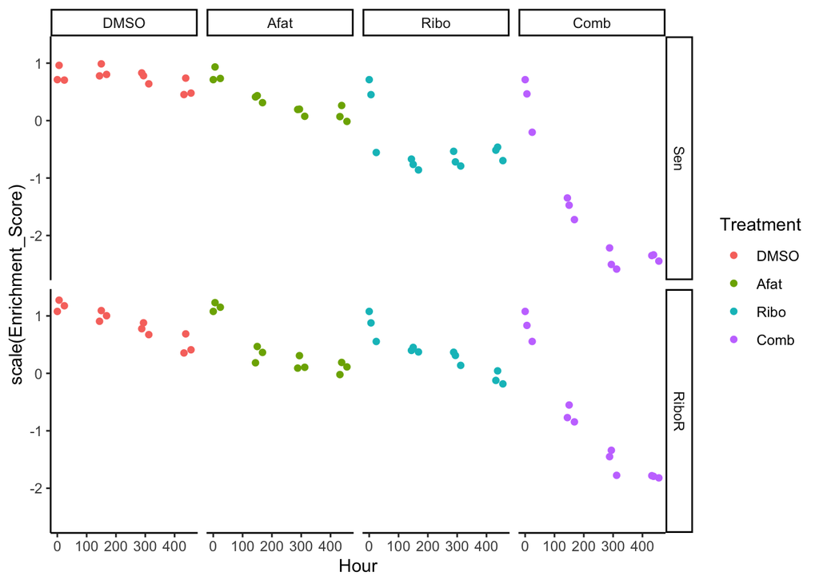

```r
fit <- dd


ggplot(fit,aes(x=Hour,y=scale(Enrichment_Score),col=Treatment,fill=Treatment,group=S_T))+
  #geom_path()+
  geom_point(shape="circle")+
  facet_grid(State~Treatment)+theme_classic()
```

## Fit model to data

To identify significant model terms more robustly, we will use shrinkage smoothers to describe each plasticity term (thin plate regression spline specified by s(…, bs=“ts”) in the model formula (technical details in Marra and Wood 2011). Shrinkage better selects key terms and provides less conservative p-values after marginalising non-significant terms.

Long term day effects have been reparameterized to detect cumulative changes from one time to the next rather than always being relative to baseline.

Afatinib and ribociclib effects reparameterized to detect monotheapy effects and synergistic/antagonistic effects of combination treatment.

Here “AfatTreated” and “RiboTreated” variables characterize main effects of any treatment given the specific drug (i.e. AfatTreated effects apply to afatinib and combination treatment).

In contrast, the “CombTreated” variable characterizes synergy effects of any treatment under combination therapy.

```r
gam_Full  <- gam( scale(Enrichment_Score) ~
      # Pre-treatment differences of S and R cells
      State +

      # Long-term cumulative phenotype change under treatment in sensitive cells
      # DMSO effects
      CumDay6 + CumDay12 + CumDay18 +
      # Afatinib effects
      AfatTreated:CumDay6 + AfatTreated:CumDay12 + AfatTreated:CumDay18 +
      # Ribociclib effects
      RiboTreated:CumDay6 + RiboTreated:CumDay12 + RiboTreated:CumDay18 +
      # Synergy effects of combination treatment
      CombTreated:CumDay6 + CombTreated:CumDay12 + CombTreated:CumDay18+

      # Resistant cell deviation in long-term cumulative phenotype change
      # DMSO effects
      State:CumDay6 + State:CumDay12 + State:CumDay18 +
      # Afatinib effects
      State:AfatTreated:CumDay6 + State:AfatTreated:CumDay12 + State:AfatTreated:CumDay18 +
      # Ribociclib effects
      State:RiboTreated:CumDay6 + State:RiboTreated:CumDay12 + State:RiboTreated:CumDay18 +
      # Synergy effects of combination treatment
      State:CombTreated:CumDay6 + State:CombTreated:CumDay12 + State:CombTreated:CumDay18+

      # Initial (day 1) response at hour 6/24 under DMSO
      isHour6 + isHour24  +
      # Resistant cell deviation in initial (day 1) response at hour 24 under DMSO
      State:isHour6 + State:isHour24 +

      # Initial (day 1) response at hour 6/24 under drug x
      # Main monotherapy effects and synergy
      AfatTreated:isHour6 + RiboTreated:isHour6 +CombTreated:isHour6 +
      AfatTreated:isHour24 + RiboTreated:isHour24 + CombTreated:isHour24  +
      # Resistant cell deviation in initial (day 1) response at hour 24 under drug x
      # Main monotherapy effects and synergy
      State:AfatTreated:isHour6 + State:RiboTreated:isHour6 + State:CombTreated:isHour6 +
      State:AfatTreated:isHour24 + State:RiboTreated:isHour24 + State:CombTreated:isHour24  +

      # Plasticity of response at hour 6/24 during DMSO treatment
      s(plastHour6,k=3, bs="ts") + s(plastHour24,k=3, bs="ts") +
      # Resistant cell deviation in plasticity of response at hour 6/24 during DMSO treatment
      s(RiboRplastHour6,k=3, bs="ts") + s(RiboRplastHour24,k=3, bs="ts") +
      # Plasticity of response at hour 6/24 during drug x treatment
      # Main monotherapy effects
      s(plastHour.AfatTreated6,k=3, bs="ts") + s(plastHour.AfatTreated24,k=3, bs="ts") +
      s(plastHour.RiboTreated6,k=3, bs="ts") + s(plastHour.RiboTreated24,k=3, bs="ts") +
      # Synergy combination effects
      s(plastHour.CombTreated6,k=3, bs="ts") + s(plastHour.CombTreated24,k=3, bs="ts") +
      # Resistant cell deviation in plasticity of response at hour 6/24 during DMSO treatment
      # Main monotherapy effects
      s(RiboRplastHour.AfatTreated6,k=3, bs="ts") + s(RiboRplastHour.AfatTreated24,k=3, bs="ts") +
      s(RiboRplastHour.RiboTreated6,k=3, bs="ts") + s(RiboRplastHour.RiboTreated24,k=3, bs="ts") +
      # Synergy combination effects
      s(RiboRplastHour.CombTreated6,k=3, bs="ts") + s(RiboRplastHour.CombTreated24,k=3, bs="ts")
                , data=fit,method="REML")
```

## Extract output tables

```r
summary(gam_Full )
```

```
##
## Family: gaussian
## Link function: identity
##
## Formula:
## scale(Enrichment_Score) ~ State + CumDay6 + CumDay12 + CumDay18 +
##     AfatTreated:CumDay6 + AfatTreated:CumDay12 + AfatTreated:CumDay18 +
##     RiboTreated:CumDay6 + RiboTreated:CumDay12 + RiboTreated:CumDay18 +
##     CombTreated:CumDay6 + CombTreated:CumDay12 + CombTreated:CumDay18 +
##     State:CumDay6 + State:CumDay12 + State:CumDay18 + State:AfatTreated:CumDay6 +
##     State:AfatTreated:CumDay12 + State:AfatTreated:CumDay18 +
##     State:RiboTreated:CumDay6 + State:RiboTreated:CumDay12 +
##     State:RiboTreated:CumDay18 + State:CombTreated:CumDay6 +
##     State:CombTreated:CumDay12 + State:CombTreated:CumDay18 +
##     isHour6 + isHour24 + State:isHour6 + State:isHour24 + AfatTreated:isHour6 +
##     RiboTreated:isHour6 + CombTreated:isHour6 + AfatTreated:isHour24 +
##     RiboTreated:isHour24 + CombTreated:isHour24 + State:AfatTreated:isHour6 +
##     State:RiboTreated:isHour6 + State:CombTreated:isHour6 + State:AfatTreated:isHour24 +
##     State:RiboTreated:isHour24 + State:CombTreated:isHour24 +
##     s(plastHour6, k = 3, bs = "ts") + s(plastHour24, k = 3, bs = "ts") +
##     s(RiboRplastHour6, k = 3, bs = "ts") + s(RiboRplastHour24,
##     k = 3, bs = "ts") + s(plastHour.AfatTreated6, k = 3, bs = "ts") +
##     s(plastHour.AfatTreated24, k = 3, bs = "ts") + s(plastHour.RiboTreated6,
##     k = 3, bs = "ts") + s(plastHour.RiboTreated24, k = 3, bs = "ts") +
##     s(plastHour.CombTreated6, k = 3, bs = "ts") + s(plastHour.CombTreated24,
##     k = 3, bs = "ts") + s(RiboRplastHour.AfatTreated6, k = 3,
##     bs = "ts") + s(RiboRplastHour.AfatTreated24, k = 3, bs = "ts") +
##     s(RiboRplastHour.RiboTreated6, k = 3, bs = "ts") + s(RiboRplastHour.RiboTreated24,
##     k = 3, bs = "ts") + s(RiboRplastHour.CombTreated6, k = 3,
##     bs = "ts") + s(RiboRplastHour.CombTreated24, k = 3, bs = "ts")
##
## Parametric coefficients:
##                                 Estimate Std. Error t value Pr(>|t|)
## (Intercept)                      0.82221    0.04160  19.764  < 2e-16 ***
## StateRiboR                       0.33325    0.04767   6.990 6.19e-09 ***
## CumDay6                          0.08074    0.06592   1.225  0.22640
## CumDay12                        -0.10422    0.07552  -1.380  0.17374
## CumDay18                        -0.19136    0.07553  -2.534  0.01447 *
## isHour6                          0.18541    0.05924   3.130  0.00291 **
## isHour24                        -0.01527    0.06189  -0.247  0.80615
```

[output cut: 46 more lines]

```
## s(plastHour.RiboTreated6)       9.417e-01      2  5.264 0.00135 **
## s(plastHour.RiboTreated24)      1.858e+00      2 40.942 < 2e-16 ***
## s(plastHour.CombTreated6)       3.356e-06      2  0.000 0.75908
## s(plastHour.CombTreated24)      2.994e-06      2  0.000 0.50952
## s(RiboRplastHour.AfatTreated6)  2.978e-06      2  0.000 0.91739
## s(RiboRplastHour.AfatTreated24) 1.660e-06      2  0.000 0.85266
## s(RiboRplastHour.RiboTreated6)  2.480e-06      2  0.000 0.75234
## s(RiboRplastHour.RiboTreated24) 9.464e-01      2  5.830 0.00086 ***
## s(RiboRplastHour.CombTreated6)  3.193e-06      2  0.000 0.78813
## s(RiboRplastHour.CombTreated24) 2.677e-06      2  0.000 0.86473
## ---
## Signif. codes:  0 '***' 0.001 '**' 0.01 '*' 0.05 '.' 0.1 ' ' 1
##
## R-sq.(adj) =  0.991   Deviance explained = 99.6%
## -REML = -20.924  Scale est. = 0.0085343  n = 96
```

```r
# making output table of parametric coefficients
Fullcoefs<-data.table(term="coef",summary(gam_Full)$p.table,keep.rownames = T)
setnames(Fullcoefs,old=c("Std. Error","t value","Pr(>|t|)"),new=c("Std.Error","tvalue","pvalue"))

# making output table for smooth terms
Fullsmooths0 <- data.table(term = "smooth", summary(gam_Full)$s.table, keep.rownames = T) # get smooth terms from GAM model output
setnames(Fullsmooths0,old=c("p-value"),new=c("pvalue"))

Fullsmooths0$smoothid  <- 1:nrow(Fullsmooths0)                                 # add row order variable to maintain ordering
s_terms <- cbind(fit, predict(gam_Full, type="terms" )[, Fullsmooths0$rn])     # predict all the smooth terms and match to data to see how they change over time
names(s_terms) <- gsub("[()]", "", names(s_terms))                             # remove brackets from col names

# Get a metric of effect of smooth: For each smooth term assess trend over time: compare initial value with values at later timepoint (excluding unchanged values)
s_effects <- rbindlist( lapply(Fullsmooths0$rn, function(i){
 tmp <- data.table(s_terms); # make temp copy
 setnames(tmp, old= gsub("[()]", "", i ) , new= "X") # remove brackets in colname and name focal col (term X)
 strt <- tmp[Hour == 0]$X[1] # get initial value of focal term (X) at hour 0
 end  <- mean(tmp[Hour != 0][X!= strt]$X) # get mean change in focal term (X) after hour 0
 data.table(rn= i, effect= end - strt)
}))

# merge smooth table and effect metric
Fullsmooths <-  merge(Fullsmooths0,s_effects, by="rn")[order(smoothid)]
Fullsmooths[,smoothid:=NULL]


Fullsmooths[,Treatment:="DMSO"]
Fullsmooths[grep(".RiboTreated",rn),Treatment:="RiboMain"]
Fullsmooths[grep(".AfatTreated",rn),Treatment:="AfatMain"]
Fullsmooths[grep(".CombTreated",rn),Treatment:="CombSynergy"]
Fullsmooths[,Hour:=6]
Fullsmooths[grep("24",rn),Hour:=24]
Fullsmooths[,State:="Sens"]
Fullsmooths[grep("RiboR",rn),State:="RiboR"]

Fullcoefs[,Treatment:="DMSO"]
Fullcoefs[grep(".RiboTreated",rn),Treatment:="RiboMain"]
Fullcoefs[grep(".AfatTreated",rn),Treatment:="AfatMain"]
Fullcoefs[grep(".CombTreated",rn),Treatment:="CombSynergy"]

Fullcoefs[,Day:=0]
Fullcoefs[grep("Day6",rn),Day:=6]
Fullcoefs[grep("Day12",rn),Day:=12]
Fullcoefs[grep("Day18",rn),Day:=18]

Fullcoefs[,State:="Sens"]
Fullcoefs[grep("RiboR",rn),State:="RiboR"]

Fullcoefs[,Timescale:="ShortTerm"]
Fullcoefs[grep("CumDay",rn),Timescale:="LongTerm"]

Fullcoefs[,Hour:=0]
Fullcoefs[grep("isHour6",rn),Hour:=6]
Fullcoefs[grep("isHour24",rn),Hour:=24]
```

## Show significant effects:

Parametric coefficient tables show pre treatment differences between sensitive and resistant cells, initial treatment impacts on day 1 under each treatment.

```r
Fullsmooths[][pvalue< 0.05]
```

```
##                                 rn   term       edf Ref.df         F
## 1:       s(plastHour.RiboTreated6) smooth 0.9416738      2  5.264015
## 2:      s(plastHour.RiboTreated24) smooth 1.8577511      2 40.941681
## 3: s(RiboRplastHour.RiboTreated24) smooth 0.9463641      2  5.829715
##          pvalue     effect Treatment Hour State
## 1: 0.0013467314  0.1279679  RiboMain    6  Sens
## 2: 0.0000000000  0.6297454  RiboMain   24  Sens
## 3: 0.0008599407 -0.2691232  RiboMain   24 RiboR
```

```r
Fullcoefs[pvalue< 0.05][order(Day,Hour,-State)]
```

```
##     term                              rn   Estimate  Std.Error     tvalue
##  1: coef                     (Intercept)  0.8222093 0.04160228  19.763564
##  2: coef                      StateRiboR  0.3332491 0.04767229   6.990415
##  3: coef                         isHour6  0.1854141 0.05923593   3.130094
##  4: coef             isHour6:RiboTreated -0.4856003 0.08637181  -5.622208
##  5: coef            isHour24:RiboTreated -1.1288609 0.09951279 -11.343877
##  6: coef StateRiboR:isHour24:RiboTreated  0.4992178 0.13154363   3.795074
##  7: coef             CumDay6:AfatTreated -0.4488910 0.08709786  -5.153869
##  8: coef             CumDay6:RiboTreated -1.3033950 0.08795560 -14.818783
##  9: coef             CumDay6:CombTreated -0.3405352 0.12317498  -2.764646
## 10: coef              StateRiboR:CumDay6 -0.2291438 0.09271517  -2.471482
## 11: coef  StateRiboR:CumDay6:RiboTreated  0.8846160 0.12322165   7.179063
## 12: coef            CumDay12:CombTreated -0.8792708 0.15085793  -5.828469
## 13: coef                        CumDay18 -0.1913617 0.07552842  -2.533639
## 14: coef            CumDay18:RiboTreated  0.2513049 0.10963956   2.292101
```

[output cut: 17 more lines]

# Prediction of timecourse using fitted model (and get residual model error)

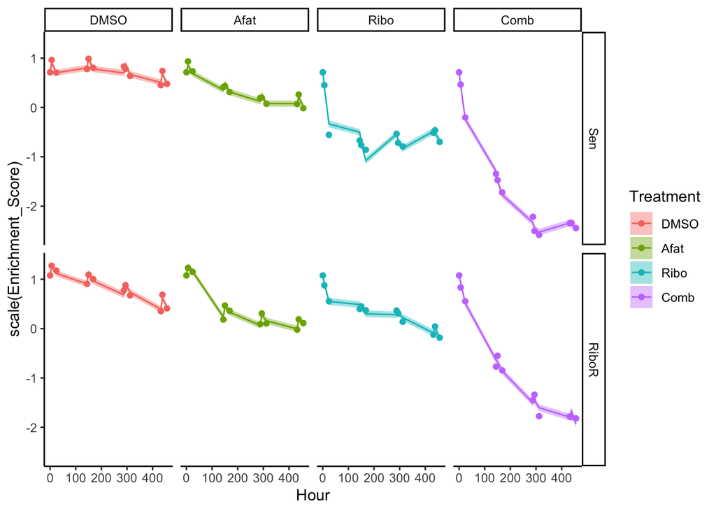

```r
fit$predFULL <- predict(gam_Full)
fit$residFULL <- residuals(gam_Full)
fit$standresids <- residuals(gam_Full, "scaled.pearson")
fit$uclFULL <- fit$predFULL+ predict(gam_Full,se=T)$se.fit
fit$lclFULL <- fit$predFULL- predict(gam_Full,se=T)$se.fit

ggplot(fit,aes(x=Hour,y=scale(Enrichment_Score),col=Treatment,fill=Treatment,group=S_T))+
  geom_ribbon(aes(ymax=uclFULL,ymin=lclFULL),col=NA,alpha=0.4)+
  geom_path(aes(y=predFULL),alpha=1)+
  geom_point(shape="circle")+
  facet_grid(State~Treatment) +theme_classic()
```

# Another way to look at the data

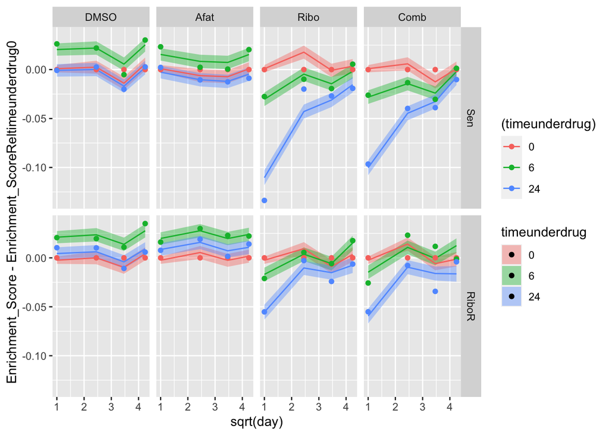

```r
# normalize relative to begining of treatment occasion (day)
fit[,Enrichment_ScoreReltimeunderdrug0:=sum(Enrichment_Score*(timeunderdrug==0)),by=c("State","Treatment","day")]

cent <- attr(scale(fit$Enrichment_Score), "scaled:center")
scl  <- attr(scale(fit$Enrichment_Score), "scaled:scale")

ggplot(fit, aes(x=sqrt(day),y=Enrichment_Score-Enrichment_ScoreReltimeunderdrug0,col=(timeunderdrug),fill=timeunderdrug,group=interaction(timeunderdrug,State,Treatment)))+facet_wrap(~CellLine)+
  geom_ribbon(aes(ymax=cent+uclFULL*scl-Enrichment_ScoreReltimeunderdrug0,
                  ymin=cent+lclFULL*scl-Enrichment_ScoreReltimeunderdrug0), col=NA, alpha=0.4)+
  geom_path(aes(y=cent+predFULL*scl-Enrichment_ScoreReltimeunderdrug0))+
  facet_grid(State~Treatment)+
  geom_point()#geom_smooth(method="lm",se=F)
```

# Evaluate model assumptions

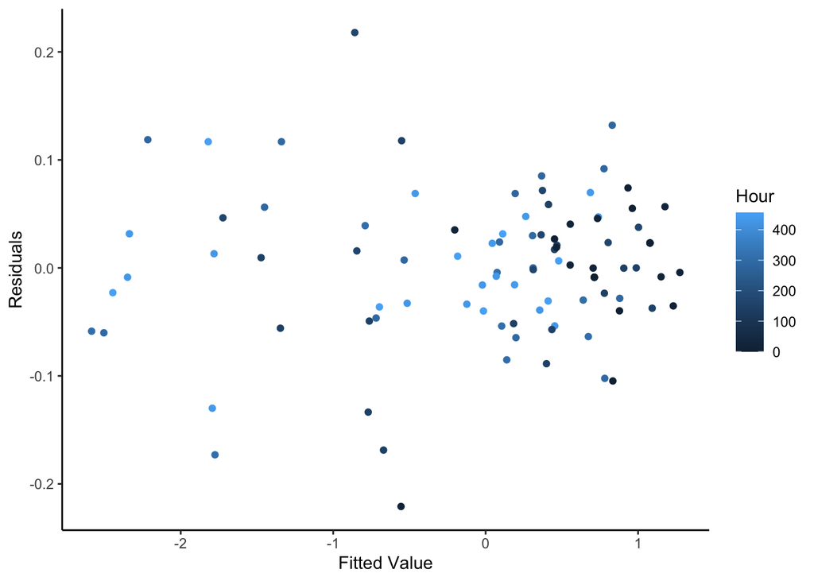

```r
# Residual non-linearity / structural misfit (residual pattern)
ggplot(fit,aes(x=scale(Enrichment_Score),y=residFULL,col=Hour,group=S_T))+
  geom_point()+theme_classic()+
  labs(x="Fitted Value",y="Residuals")
```

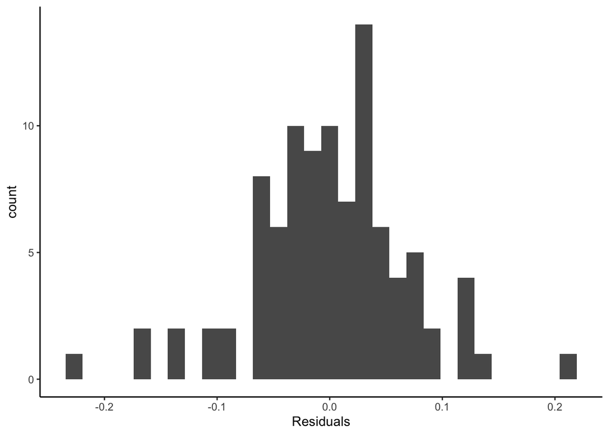

```r
# Normality of residuals
ggplot(fit,aes(x=residFULL)) + geom_histogram()+theme_classic()+
  labs(x="Residuals")
```

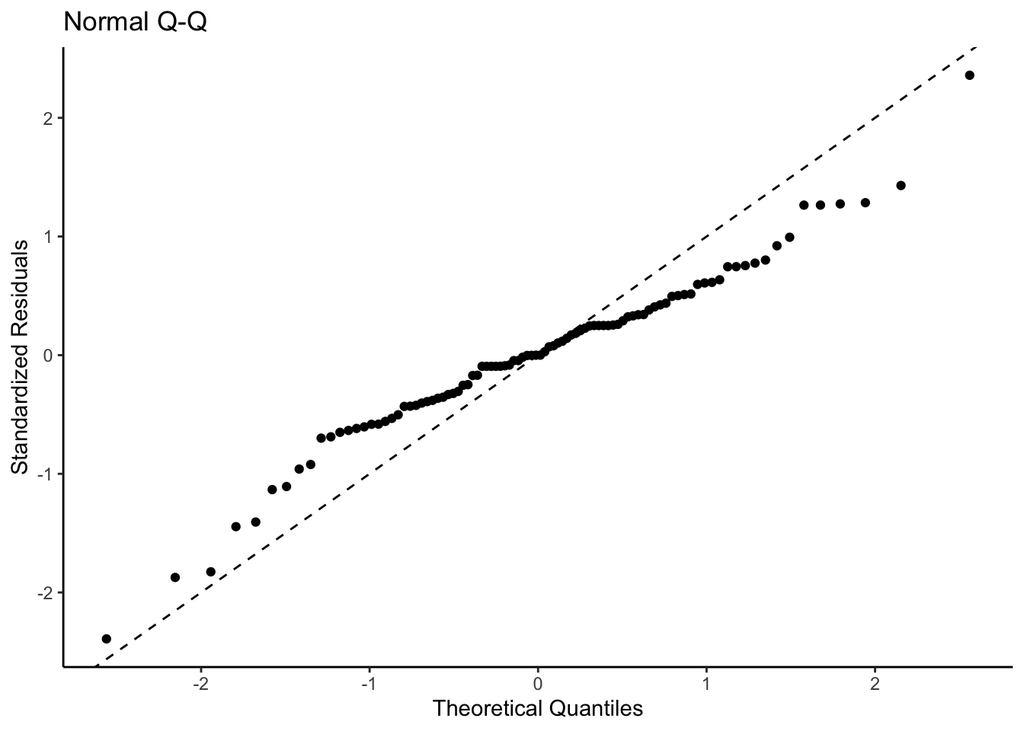

```r
ggplot(fit, aes(qqnorm(standresids)[[1]], standresids))+geom_point(na.rm = TRUE)+
  geom_abline(linetype="dashed")+
  labs(x="Theoretical Quantiles",y="Standardized Residuals")+ggtitle("Normal Q-Q")+theme_classic()
```

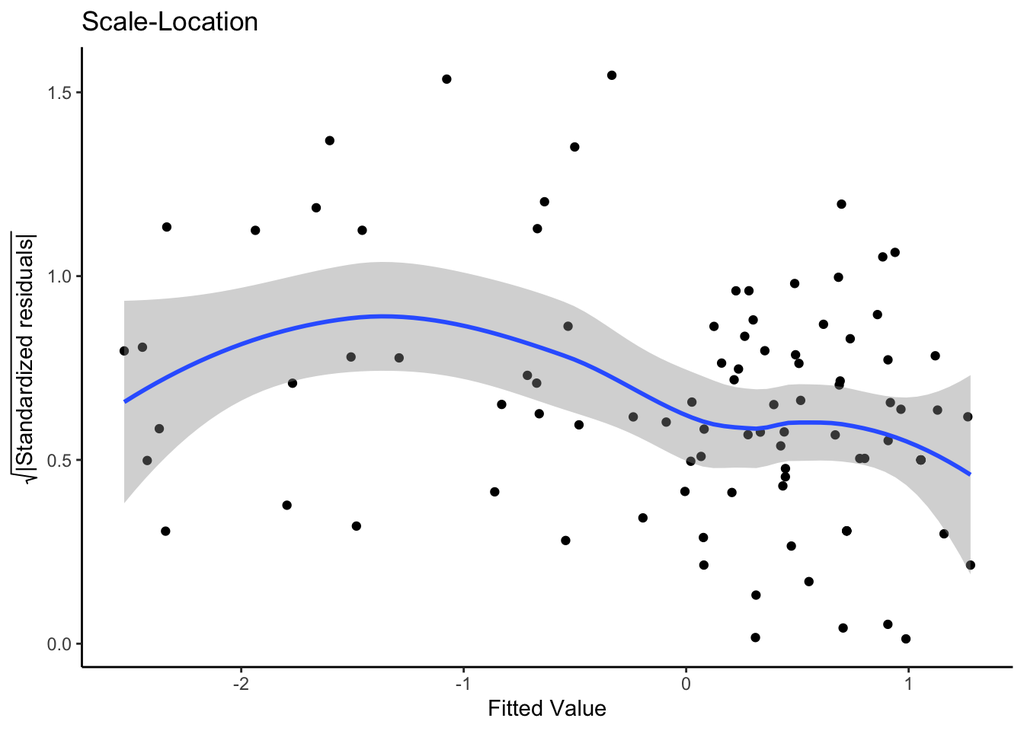

```r
# Equal variance (homoscedasticity)
ggplot(fit, aes(predFULL, sqrt(abs(standresids))))+geom_point()+ggtitle("Scale-Location")+
  stat_smooth(method="loess", na.rm = TRUE)+
  labs(x="Fitted Value",y=expression(sqrt("|Standardized residuals|")))+theme_classic()
```